# DNAm Smoking Exposure Signature

Lauren Vanderlinden

Report generated: December 14, 2022

# Overview

Making 2 different DNAm smoking signatures based on Reese 2017 (https://pubmed.ncbi.nlm.nih.gov/27323799/) and on McCartney 2018 (https://pubmed.ncbi.nlm.nih.gov/30257690/).

Going to create these scores on EVERY SAMPLE that has DNAm. Then depending on the analyses, folks can subset and/or dichotomize as needed. Just a reminder in the full datasets we have **687** samples on the 450K and **475** samples on the EPIC.

# Reese

```r
reese = read.csv(file="C:/Users/vanderll/Documents/Norris/smokingExposure_DNAmSignature/dataRaw/Reese_CpG_weights.csv")
load(file="C:/Users/vanderll/Documents/Norris/smokingExposure_DNAmSignature/data/Reese_McCartney_DNAm_beta_datasets.Rdata")

beta.450.reese.2 = beta.450.reese[which(rownames(beta.450.reese) %in% rownames(beta.EPIC.reese)),]

#table(rownames(beta.450.reese.2) == rownames(beta.EPIC.reese))

reese.want = reese[which(reese$CpG %in% rownames(beta.450.reese.2)),]

#table(rownames(beta.450.reese.2) == reese.want$CpG)
order = c()
for(i in 1:nrow(reese.want)){
  order = c(order, which(reese.want$CpG == rownames(beta.450.reese.2)[i]))
}
reese.want = reese.want[order,]
#table(rownames(beta.450.reese.2) == reese.want$CpG)

DNAm.smoke.reese = as.numeric(t(as.matrix(reese.want$Coefficient)) %*% beta.450.reese.2)
DNAm.smoke.reese = data.frame(array = colnames(beta.450.reese.2), DNAm.smoke.reese, platform="450K")

DNAm.smoke.reese.epic = as.numeric(t(as.matrix(reese.want$Coefficient)) %*% beta.EPIC.reese)
DNAm.smoke.reese.epic = data.frame(array = colnames(beta.EPIC.reese), DNAm.smoke.reese.epic, platform="EPIC")

colnames(DNAm.smoke.reese) = c("array", "DNAm.smoke.Reese", "platform")
colnames(DNAm.smoke.reese.epic) = c("array", "DNAm.smoke.Reese", "platform")

DNAm.smoke.reese = rbind(DNAm.smoke.reese, DNAm.smoke.reese.epic)
```

Reese reports **28 CpGs** for their signature. Of these **21** are present and high quality on both our 450K and EPIC arrays. Going to create score off of these 21 CpG probes. These probes are cg25189904, cg26764244, cg14179389, cg02482603, cg04506190, cg05575921, cg17397069, cg14633298, cg19381766, cg22154659, cg04180046, cg25949550, cg14743346, cg11864574, cg22802102, cg08698721, cg05549655, cg13834112, cg09743950, cg02256631, cg12186702.

What are we missing?

```r
toPlot.score = data.frame(table(c(reese$CpG, reese.want$CpG)))
colnames(toPlot.score) = c("CpG", "n")

toPlot.score$InCalc = as.numeric(toPlot.score$n==2)

toPlot.score = merge(toPlot.score, reese, by="CpG")
toPlot.score = toPlot.score[order(abs(toPlot.score$Coefficient), decreasing=T),]

datatable(toPlot.score[,-2], rownames=FALSE)
```

| CpG | InCalc | Coefficient | Gene |
| --- | --- | --- | --- |
| cg25949550 | 1 | -46.991 | CNTNAP2 |
| cg04180046 | 1 | 14.027 | MYO1G |
| cg05575921 | 1 | -10.909 | AHRR |
| cg14351425 | 0 | 6.361 | GRK5 |
| cg09743950 | 1 | -6.33 | ITGAM |
| cg14179389 | 1 | -6.304 | GFI1 |
| cg05549655 | 1 | 6.21 | CYP1A1 |
| cg19381766 | 1 | 5.245 |  |
| cg14633298 | 1 | 5.05 | TRIM27 |
| cg10799846 | 0 | -4.963 | SYNJ2 |

[output cut: 18 more lines]

```r
#kable(toPlot.score[,-2], row.names=0, align='l')  %>%
 # kable_styling(bootstrap_options = c("striped", "hover"), full_width = F)
```

Let’s look at the distribution of the scores.

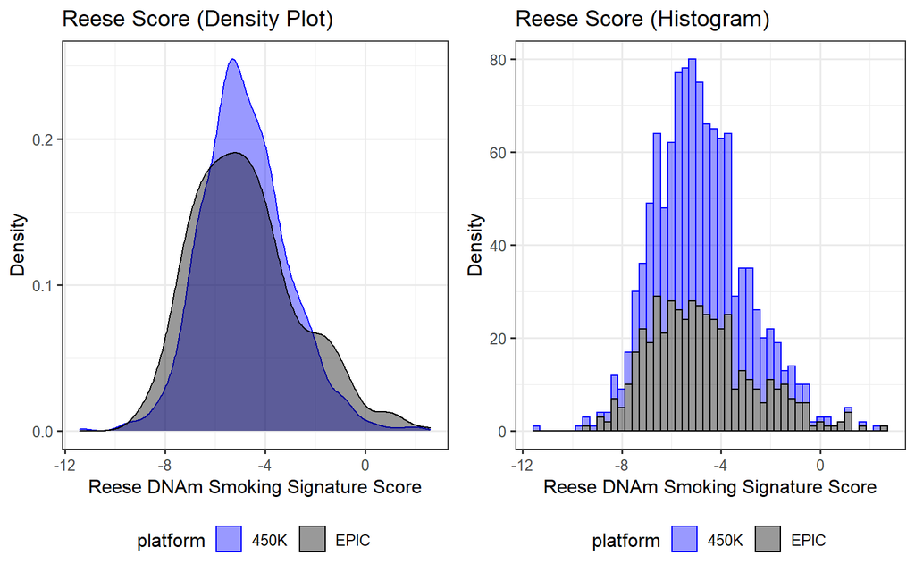

```r
d = ggplot(DNAm.smoke.reese, aes(x=DNAm.smoke.Reese, colour=platform, fill=platform)) + #geom_histogram(alpha=0.5, bins=50) +
   geom_density(alpha=0.4)+
  scale_color_manual(values=c("blue", "black"))+  scale_fill_manual(values=c("blue", "black")) +
  xlab("Reese DNAm Smoking Signature Score") + ylab("Density") +
  theme_bw(base_size=12) +
  ggtitle("Reese Score (Density Plot)")+ theme(legend.position="bottom")

a = ggplot(DNAm.smoke.reese, aes(x=DNAm.smoke.Reese, colour=platform, fill=platform)) + geom_histogram(alpha=0.4, bins=50) +
   #geom_density(alpha=0.4)+
  scale_color_manual(values=c("blue", "black"))+  scale_fill_manual(values=c("blue", "black")) +
  xlab("Reese DNAm Smoking Signature Score") + ylab("Density") +
  theme_bw(base_size=12) +
  ggtitle("Reese Score (Histogram)")+ theme(legend.position="bottom")
ggarrange(d, a, ncol=2)
```

```r
reese.summary = tapply(DNAm.smoke.reese$DNAm.smoke.Reese, DNAm.smoke.reese$platform, summary)
toPrint = data.frame(measure = names(reese.summary[[2]]), p450K = round(as.numeric(reese.summary[[1]]),2), EPIC=round(as.numeric(reese.summary[[2]]),2))
colnames(toPrint) = c("Summary Measure", "450K", "EPIC")

kable(toPrint, row.names=0, align='l')  %>%
  kable_styling(bootstrap_options = c("striped", "hover"), full_width = F)
```

| Summary Measure | 450K | EPIC |
| --- | --- | --- |
| Min. | -11.43 | -9.33 |
| 1st Qu. | -5.88 | -6.42 |
| Median | -4.96 | -5.06 |
| Mean | -4.81 | -4.81 |
| 3rd Qu. | -3.79 | -3.68 |
| Max. | 2.16 | 2.59 |

# McCartney

```r
mccartney = read.csv(file="C:/Users/vanderll/Documents/Norris/smokingExposure_DNAmSignature/dataRaw/McCartney_CpG_weights.csv")

test = data.frame(table(c(rownames(beta.450.mccartney), rownames(beta.EPIC.mccartney))))
cpg.want = test$Var1[which(test$Freq==2)]

beta.450.mccartney.2 = beta.450.mccartney[which(rownames(beta.450.mccartney) %in% cpg.want),]
beta.EPIC.mccartney.2 = beta.EPIC.mccartney[which(rownames(beta.EPIC.mccartney) %in% cpg.want),]

table(rownames(beta.450.mccartney.2) == rownames(beta.EPIC.mccartney.2))
```

```
##
## TRUE
##  170
```

```r
mccartney.want = mccartney[which(mccartney$CpG %in% rownames(beta.450.mccartney.2)),]

mccartney.want = mccartney[which(mccartney$CpG %in% cpg.want),]
#table(rownames(beta.450.mccartney.2) == mccartney.want$CpG)

order = c()
for(i in 1:nrow(mccartney.want)){
  order = c(order, which(mccartney.want$CpG == rownames(beta.450.mccartney.2)[i]))
}
mccartney.want = mccartney.want[order,]
#table(rownames(beta.450.mccartney.2) == mccartney.want$CpG)

DNAm.smoke.mccartney = as.numeric(t(as.matrix(mccartney.want$Beta)) %*% beta.450.mccartney.2)
DNAm.smoke.mccartney = data.frame(array = colnames(beta.450.mccartney.2), DNAm.smoke.mccartney, platform="450K")

DNAm.smoke.mccartney.epic = as.numeric(t(as.matrix(mccartney.want$Beta)) %*% beta.EPIC.mccartney.2)
DNAm.smoke.mccartney.epic = data.frame(array = colnames(beta.EPIC.mccartney.2), DNAm.smoke.mccartney.epic, platform="EPIC")

colnames(DNAm.smoke.mccartney) = c("array", "DNAm.smoke.McCartney", "platform")
colnames(DNAm.smoke.mccartney.epic) = c("array", "DNAm.smoke.McCartney", "platform")

DNAm.smoke.mccartney = rbind(DNAm.smoke.mccartney, DNAm.smoke.mccartney.epic)
```

McCartney reports **233 CpGs** for their signature. Of these **170** are present and high quality on both our 450K and EPIC arrays. Going to create score off of these 170 CpG probes.

What are we missing?

```r
toPlot.score = data.frame(table(c(mccartney$CpG, mccartney.want$CpG)))
colnames(toPlot.score) = c("CpG", "n")

toPlot.score$InCalc = as.numeric(toPlot.score$n==2)

toPlot.score = merge(toPlot.score, mccartney, by="CpG")
toPlot.score = toPlot.score[order(abs(toPlot.score$Beta), decreasing=T),]

datatable(toPlot.score[,-2], rownames=FALSE)
```

| CpG | InCalc | Beta |
| --- | --- | --- |
| cg05575921 | 1 | -5.877943289 |
| cg21566642 | 1 | -2.413874413 |
| cg10573386 | 1 | 1.516013954 |
| cg13560072 | 1 | 1.395849817 |
| cg25013095 | 1 | -1.363475197 |
| cg11084015 | 1 | 1.283488076 |
| cg10321266 | 1 | 1.262161273 |
| cg03636183 | 1 | -1.06399332 |
| cg12651044 | 1 | -1.060986046 |
| cg07597069 | 1 | 0.919146553 |

[output cut: 223 more lines]

```r
#kable(toPlot.score[,-2], row.names=0, align='l')  %>%
 # kable_styling(bootstrap_options = c("striped", "hover"), full_width = F)
```

Let’s look at the distribution of the scores.

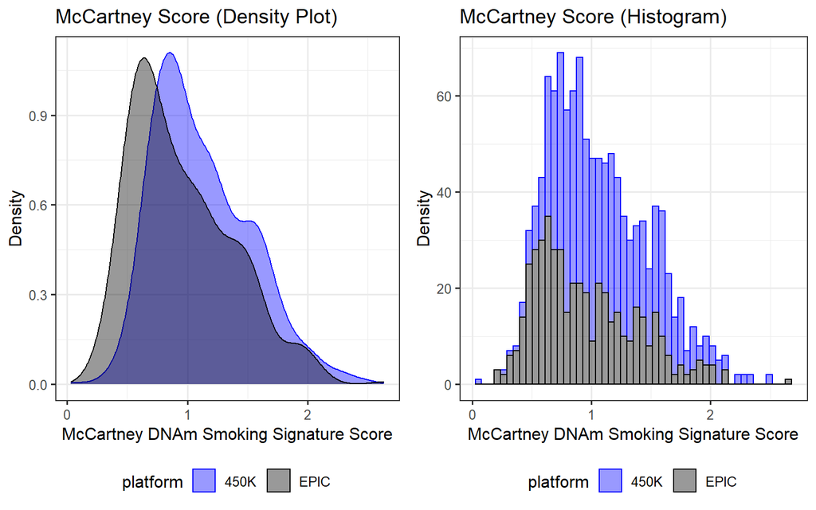

```r
d = ggplot(DNAm.smoke.mccartney, aes(x=DNAm.smoke.McCartney, colour=platform, fill=platform)) + #geom_histogram(alpha=0.5, bins=50) +
   geom_density(alpha=0.4)+
  scale_color_manual(values=c("blue", "black"))+  scale_fill_manual(values=c("blue", "black")) +
  xlab("McCartney DNAm Smoking Signature Score") + ylab("Density") +
  theme_bw(base_size=12) +
  ggtitle("McCartney Score (Density Plot)")+ theme(legend.position="bottom")

a = ggplot(DNAm.smoke.mccartney, aes(x=DNAm.smoke.McCartney, colour=platform, fill=platform)) + geom_histogram(alpha=0.4, bins=50) +
   #geom_density(alpha=0.4)+
  scale_color_manual(values=c("blue", "black"))+  scale_fill_manual(values=c("blue", "black")) +
  xlab("McCartney DNAm Smoking Signature Score") + ylab("Density") +
  theme_bw(base_size=12) +
  ggtitle("McCartney Score (Histogram)")+ theme(legend.position="bottom")
ggarrange(d, a, ncol=2)
```

```r
mccartney.summary = tapply(DNAm.smoke.mccartney$DNAm.smoke.McCartney, DNAm.smoke.mccartney$platform, summary)
toPrint = data.frame(measure = names(mccartney.summary[[2]]), p450K = round(as.numeric(mccartney.summary[[1]]),2), EPIC=round(as.numeric(mccartney.summary[[2]]),2))
colnames(toPrint) = c("Summary Measure", "450K", "EPIC")

kable(toPrint, row.names=0, align='l')  %>%
  kable_styling(bootstrap_options = c("striped", "hover"), full_width = F)
```

| Summary Measure | 450K | EPIC |
| --- | --- | --- |
| Min. | 0.03 | 0.21 |
| 1st Qu. | 0.81 | 0.62 |
| Median | 1.04 | 0.86 |
| Mean | 1.12 | 0.95 |
| 3rd Qu. | 1.40 | 1.23 |
| Max. | 2.48 | 2.63 |

# Comparison Of Scores

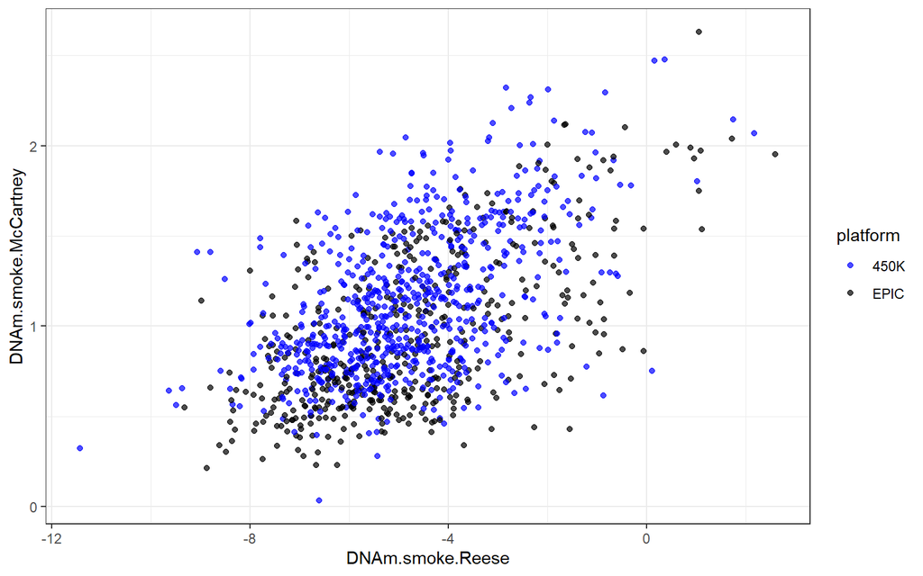

```r
both.smokes = merge(DNAm.smoke.mccartney, DNAm.smoke.reese, by=c("array", "platform"))

ggplot(both.smokes, aes(x = DNAm.smoke.Reese, y = DNAm.smoke.McCartney, color = platform)) +
  geom_point(alpha=0.7)+
  scale_color_manual(values=c("blue", "black"))+
  scale_fill_manual(values=c("blue", "black")) +
  #geom_smooth(method = "lm", se = FALSE) +
  theme_bw()
```

```r
cor.both = cor.test(x=both.smokes$DNAm.smoke.Reese, y = both.smokes$DNAm.smoke.McCartney)
cor.450 = cor.test(x=both.smokes$DNAm.smoke.Reese[which(both.smokes$platform=="450K")], y = both.smokes$DNAm.smoke.McCartney[which(both.smokes$platform=="450K")])
cor.EPIC = cor.test(x=both.smokes$DNAm.smoke.Reese[which(both.smokes$platform=="EPIC")], y = both.smokes$DNAm.smoke.McCartney[which(both.smokes$platform=="EPIC")])

toPrint = data.frame(data = c("Both Platforms", "450K", "EPIC"), correlation = round(c(cor.both$estimate, cor.450$estimate, cor.EPIC$estimate), 3), pvalue = formatC(c(cor.both$p.value, cor.450$p.value, cor.EPIC$p.value), format="e", digits=2))
colnames(toPrint) = c("Data", "Correlation Coefficient", "p-value")

kable(toPrint, row.names=0, align='l')  %>%
 kable_styling(bootstrap_options = c("striped", "hover"), full_width = F)
```

| Data | Correlation Coefficient | p-value |
| --- | --- | --- |
| Both Platforms | 0.550 | 1.01e-92 |
| 450K | 0.524 | 1.21e-49 |
| EPIC | 0.606 | 6.82e-49 |